**Loading and Summarizing GWTG Data in R**

**Laura Stevens, Remy Poudel, Raakhee Iyer**

**August 2020**

# Introduction and Software

This notebook walks through loading, viewing and summarizing a GWTG dataset comprised of a sas7bdat data file and a sas7bcat formats file. The Tables and Summary statistics section provides a brief introduction for how to calculate frequencies and distribution statistics for categorical and continuous variables respectively.

### Software

This tutorial is completed using R and provides R studio examples. All packages and libraries used in this tutorial are listed and installed in the sections below. Packages used in this tutorial as well as additional packages that are useful for tabulating and summarizing data are listed in the References Section.

### Using R Studio

- As shown below, the username and password for R Studio is *rstudio* and *workspace* respectively. Passwords and log in information are provided upon starting a workspace as well as available in the ReadMe.ipynb in /mnt/workspace.
- This tutorial is accompanied with a R_covid19_cvd_data_usage.R File which can be opened and used in R Studio.

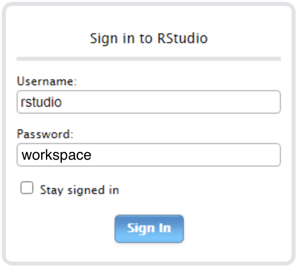

### Packages Installation

The following packages are used for this tutorial. Packages only need to be installed once. After initial installation, the cell below can be skipped or commented out (using "#").

```r
#package to load sas files
install.packages('haven')
```

### Libraries

Once all packages have been installed they can be used through the library() command. The code below loads all libraries for the tutorial

```r
library(haven)
```

# Load and View Data

The root directory path in the workspace is **/mnt/workspace**, and is the directory for the files listed under the Jupyter Home tab as well as the default working directory for Jupyter, JupyterLab, R Studio,and SAS Studio.

**AHA COVID-19 CVD Registry Powered by Get With the Guidelines® Data**

The data, documentation, and usage examples are available in the following workspace folders:

- **Data:** `/mnt/workspace/GWTG/COVID19/data` (includes data and format sas files)
- **Documentation:** `/mnt/workspace/GWTG/COVID19/documentation`.

For a more in-depth introduction to the data, check the [COVID-19 CVD Registry Researcher Resource](https://precision.heart.org/documentation/AHA-COVID19-CVD-GWTG/index.html). The Explore and Discover section of this website can be used to review all documentation and explore variables available. The website is bookmarked in the favorites bar above.

```r
dataFile = '/mnt/workspace/GWTG/COVID19/data/covid19_cvd_final_aug20.sas7bdat'
formatsFile = '/mnt/workspace/GWTG/COVID19/data/R_Python_windows_formats.sas7bcat'
```

### Loading SAS files in R

```r
df <- read_sas(dataFile, formatsFile)
```